# Histogram Guide

**For SMASH CS Fundamentals II: Data Analysis**  
This guide teaches you how you create basic histograms with **matplotlib**.

matplotlib.pyplot API:  
https://matplotlib.org/api/pyplot_api.html

## Import matplotlib.pyplot as plt and randint from random

```python
import matplotlib.pyplot as plt
from random import randint
```

## Create your data

Let's generate a pseudo-random list of exam scores.  
This isn't realistic at all. Just need some numbers to work with.

```python
scores = []
for i in range(0, 30):
    scores.append(randint(50, 100))
```

## Calculate mean and standard deviation

It's always good to include these in our histogram.  
They can help folks understand what they see.  
We'll make functions to do math for us.

```python
# Returns mean, rounded to nearest hundreth decimal place
def get_mean(nums):
    if(len(nums) == 0):
        return 0
    else:
        total = 0
        for num in nums:
            total += num
        return round(total / len(nums), 2)

# Returns standard deviation, rounded to nearest hundred decimal place
def get_sd(nums):
    mean = get_mean(nums)
    total = 0
    for num in nums:
        total += (num - mean) ** 2
    variance = total / (len(nums) - 1)
    return round(variance ** 0.5, 2)

mean = get_mean(scores)
sd = get_sd(scores)
```

## Setup your graphic

This part is very similar to how you did the bar chart.

```python
# My x_range is based on how I created my random list of scores.
x_range = list(range(50, 100, 10))

# The y_range is just as before, only now the maximum is the # of students
y_range = list(range(0, len(scores)))

# Again, place this above all of your figures.
# It just ensures gridlines appear behind everything else.
plt.rc("axes", axisbelow=True)

# Give this figure a unique number.
plt.figure(1)

# Create x-axis tickmarks according to the x_range.
plt.xticks(x_range)

# Create the y-axis tickmarks according to the y_range.
plt.yticks(y_range)

# Create horizontal gridlines so it's easier to measure the bars.
plt.grid(axis="y")

# What's the name of your graphic?
# I'm using \N{DEGREE SIGN} ensure the degree sign goes before F.
# And of course, \n just puts everything after it on the next line.
plt.title('Distribution of Exam Scores\nmean = {} sd = {}'.format(mean, sd))

# So let's label the axes.
plt.xlabel("Scores")
plt.ylabel("Frequency")
```

## Deciding the number of bins

Drawing the histogram isn't much different from drawing bar charts.  
The biggest difference is deciding how many "bins" there are.  
"bins" are the number of intervals (e.g., scores 0-10, 11-20, 21-30)  
If you've done stem and leaf plots, you know exactly what a bin is.  
Here is an example:

[figure not shown]

The histogram is kind of like taking that and flipping it 90 degrees to the left.  
matplotlib can determine the size of each bin ("bin width"), so long as you tell it how many you need.  
But...how many *do* you need?  
Click here, and scroll down to **"Choosing the Correct Bin Width"**: https://statistics.laerd.com/statistical-guides/understanding-histograms.php  
In conclusion, you'll just have to eyeball it. Generally, you'll want somewhere between **5-20 bins**.  
matplotlib can do it for you if you choose "auto". But you can enter a number too if you'd like.

## Draw the histogram

We will use "auto" to let matplotlib decide how many bins we need.  
If your histogram doesn't look right, you should enter your own value.

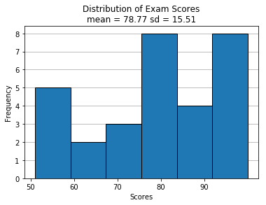

```python
# Draw the histogram.
plt.hist(scores, bins="auto", edgecolor="black")

# Show the figure.
plt.show()
```

## That's all!

There is more to histograms, but this is all you'll need for this course.  
I suggest playing around with this more until you feel more comfortable.  
And you can learn a lot by utilizing the excellent documentation I linked at the top.